# Visión Global del Desarrollo Humano: Evolución de la Esperanza de Vida (1952–2007)

Efraín Carlos Balbuena Cárdenas Hanghell Cornejo Rodríguez Johana Guadalupe Milagros Inga Gamarra Roger Guerra Quispe

2026-05-15

# Objetivo del Dashboard

## Objetivo

Analizar la evolución del bienestar humano global entre 1952 y 2007 mediante la relación entre el PIB per cápita y la esperanza de vida, considerando además el tamaño poblacional y las diferencias regionales, con el fin de identificar patrones de desarrollo económico y avances en salud pública.

## Enlaces del Proyecto

### Dashboard publicado

https://johanaiga.shinyapps.io/Avance_PAC/

### Repositorio GitHub

https://github.com/Mil254/Avance_PAC

# Características de la Base de Datos

## Dataset utilizado

El dashboard utiliza información histórica proveniente de la base de datos Gapminder, la cual contiene indicadores demográficos y económicos de diversos países alrededor del mundo entre 1952 y 2007.

# Variables Utilizadas

[output not shown]

# Descripción del Dashboard

## Descripción general

El dashboard fue desarrollado utilizando R, Shiny y shinydashboard con el objetivo de facilitar el análisis visual e interactivo de la evolución de la esperanza de vida y del crecimiento económico mundial.

La aplicación integra gráficos dinámicos, filtros interactivos y tablas descriptivas que permiten explorar los datos históricos por continente, país y periodo temporal.

# Tecnologías Utilizadas

## Herramientas implementadas

- R
- Shiny
- shinydashboard
- ggplot2
- plotly
- DT
- dplyr
- gapminder
- gganimate

# Funcionalidades Principales

## Filtros Globales

Esto permite realizar exploraciones dinámicas y personalizadas de los datos.

# Funcionalidades Principales

## Gráfico de Burbujas Animado

El gráfico de burbujas animado constituye uno de los componentes principales del dashboard.

### Variables representadas

- Eje X: PIB per cápita
- Eje Y: Esperanza de vida
- Tamaño de burbuja: población
- Color: continente
- Animación: evolución temporal entre 1952 y 2007

Este gráfico permite visualizar la evolución simultánea del desarrollo económico y la salud pública.

# Funcionalidades Principales

## Estadísticas Descriptivas

El dashboard incorpora herramientas estadísticas como:

- Histogramas
- Boxplots
- Comparaciones por continente
- Tablas descriptivas

Estas visualizaciones permiten identificar patrones, dispersión y diferencias regionales.

# Funcionalidades Principales

## Tablas Interactivas

Las tablas desarrolladas con DT permiten:

- Filtrar información
- Ordenar variables
- Buscar registros específicos
- Descargar información

Esto facilita la exploración y portabilidad de los datos.

# Capturas del Dashboard

## Página principal

[figure not shown]

# Capturas del Dashboard

## Gráfico animado

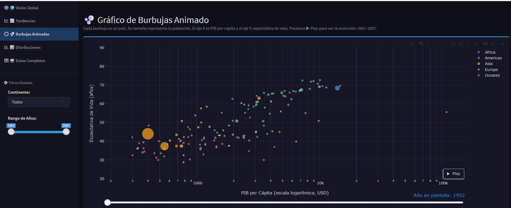

# Capturas del Dashboard

## Estadísticas descriptivas

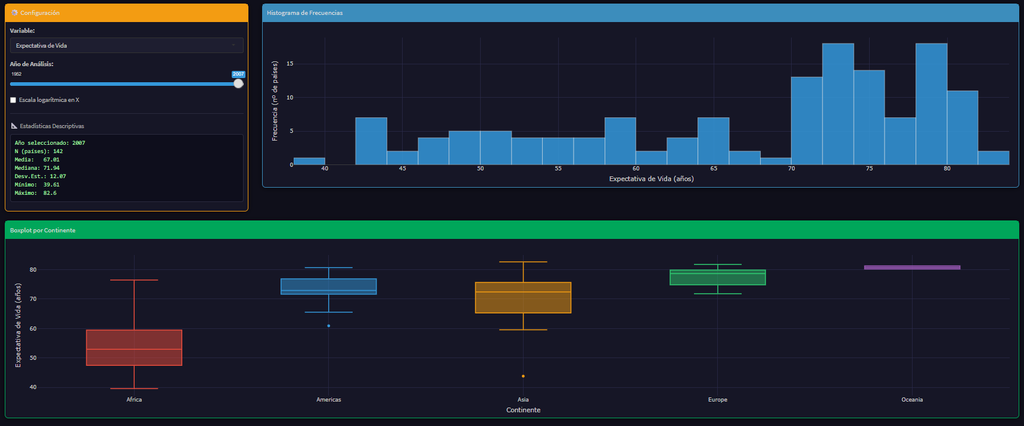

# Ventajas del Dashboard

- Interactividad y exploración dinámica mediante filtros globales.
- Visualización intuitiva de tendencias históricas mediante gráficos animados.
- Comparación multidimensional entre países y continentes.
- Incorporación de herramientas estadísticas descriptivas.
- Posibilidad de descarga y consulta dinámica de datos.

# Limitaciones

- Restricción temporal al periodo 1952–2007.
- Simplificación del análisis a tres variables principales.
- Dependencia de la calidad de los datos de Gapminder.
- Necesidad de conocimientos básicos de interpretación estadística.

## Agenda pendiente

- Ranking Top 10 de países con mayor esperanza de vida.
- Nuevos gráficos animados con Plotly.
- Implementación de análisis de correlación y regresión.
- Incorporación de nuevas variables socioeconómicas.

# Conclusiones

El dashboard permite analizar de manera interactiva la evolución histórica del bienestar humano global.

La integración de herramientas visuales y estadísticas facilita la comprensión de la relación entre crecimiento económico y esperanza de vida, evidenciando diferencias regionales y patrones de desarrollo humano.

Asimismo, el proyecto demuestra el potencial de R y Shiny para la construcción de sistemas interactivos de análisis de datos.

# Referencia Bibliográfica

Gapminder Foundation. (s. f.). *Gapminder Data*. Recuperado de: https://www.gapminder.org/data/